# Homework 6

Ashley Vang

10/16/2022

#Original Code # Can you improve this analysis code? library(bio3d)

We can see some errors in the code which we can fix. Change the s1 from the s3.b code into s3.

```r
library(bio3d)
s1 <- read.pdb("4AKE")  # kinase with drug
```

```
##   Note: Accessing on-line PDB file
```

```r
s2 <- read.pdb("1AKE")  # kinase no drug
```

```
##   Note: Accessing on-line PDB file
##    PDB has ALT records, taking A only, rm.alt=TRUE
```

```r
s3 <- read.pdb("1E4Y")  # kinase with drug
```

```
##   Note: Accessing on-line PDB file
```

```r
s1.chainA <- trim.pdb(s1, chain="A", elety="CA")
s2.chainA <- trim.pdb(s2, chain="A", elety="CA")
s3.chainA <- trim.pdb(s3, chain="A", elety="CA")
s1.b <- s1.chainA$atom$b
s2.b <- s2.chainA$atom$b
s3.b <- s3.chainA$atom$b
plotb3(s1.b, sse=s1.chainA, typ="l", ylab="Bfactor")
```

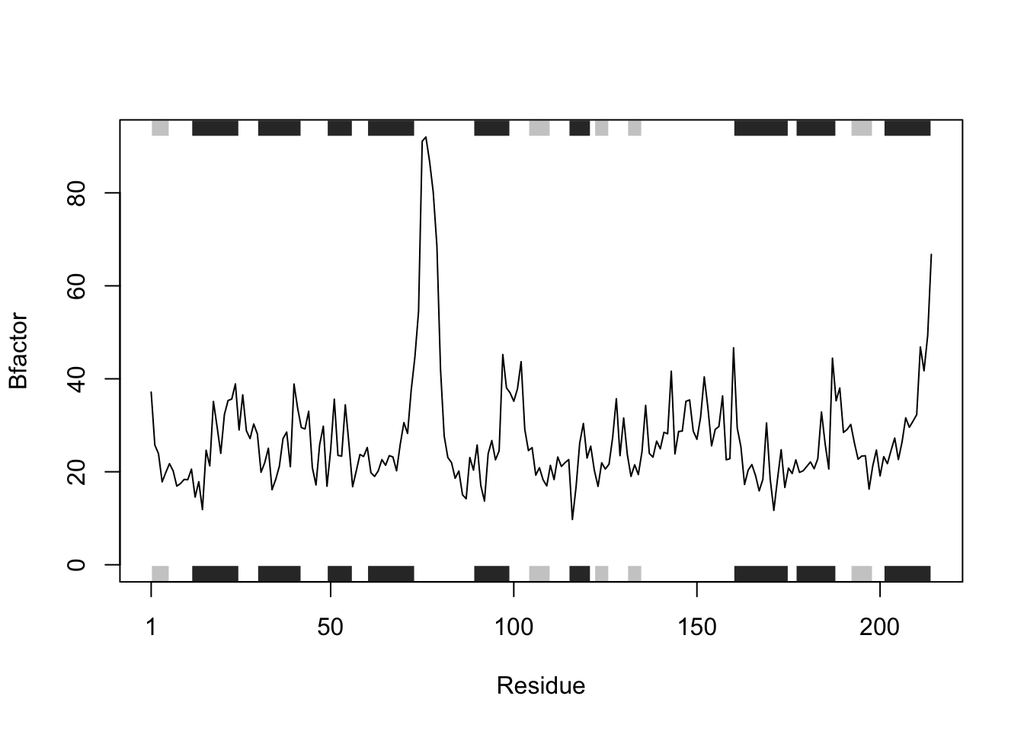

```r
plotb3(s2.b, sse=s2.chainA, typ="l", ylab="Bfactor")
```

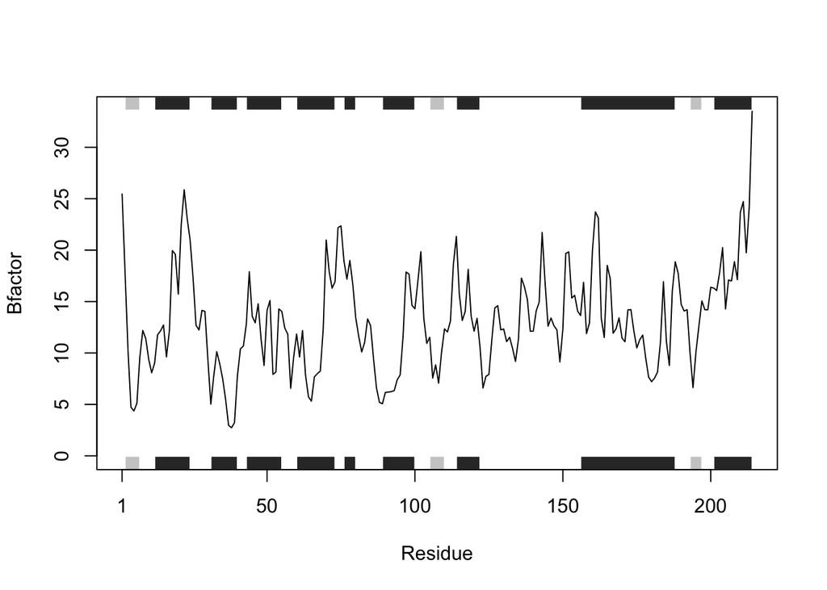

```r
plotb3(s3.b, sse=s3.chainA, typ="l", ylab="Bfactor")
```

[output not shown]

Notice how the code has elements that are specific and can be turned into a singular function such as read.pdb, trim.pdb, s.chainA$atom$b, plotb3

Set repeats as specific names so we can input it easier into the functions. Set x <- to any protein in the pdb

```r
x<- "specific protein"
x.chainA <- trim.pdb(s1, chain="A", elety="CA")

c<- x.chainA
x.b <- c$atom$b


plotb3(x.b,sse=x.chainA, typ="l", ylab="Bfactor")
```

Then input into a function using the three elements of a written function.

Refresher:All functions in R consist of at least 3 things:

-A **name** (we can pick this but it must start with a character) -Input **arguments** (there can be multiple comma separated inputs) -The **body** (where work actually happens)

```r
protein <- function(x) { x.chainA <- trim.pdb (x, chain="A", elety="CA")
c<- x.chainA
x.b <- c$atom$b

plotb3(x.b,sse=x.chainA, typ="l", ylab="Bfactor")}
```

Test to see if it works…

```r
protein(s1)
```

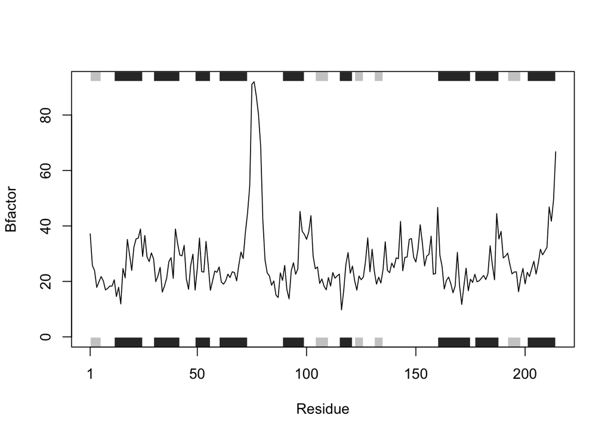

```r
protein(s2)
```

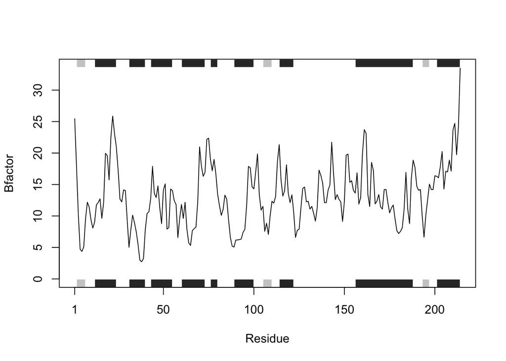

```r
protein(s3)
```

[output not shown]